# Machine Learning Project

Timothy Groth

Sunday, September 21, 2014

# Data and Package Loading

Data is read in, packages are loaded.

```r
library("caret")
library("ada")
library("randomForest")
exploreassignment <- read.csv("pml-training.csv")
```

# Initial Considerations

Initial exploration of the data and its source indicates a great deal of variables with many NAs. These variables are dropped as they will not be as useful predictors. As a note these are the summary metrics derived from the more direct observations that remain. Some factor variables that do not have NAs but have similar issues and are also summary metrics are similarly dropped.

Variables of identification were also removed due to a priori assumption of irrelevance.

```r
exclude <- grep("^amplitude",names(exploreassignment))
workingSet <- exploreassignment[,-exclude]
exclude <- grep("^var",names(workingSet))
workingSet <- workingSet[,-exclude]
exclude <- grep("^avg",names(workingSet))
workingSet <- workingSet[,-exclude]
exclude <- grep("^min",names(workingSet))
workingSet <- workingSet[,-exclude]
exclude <- grep("^max",names(workingSet))
workingSet <- workingSet[,-exclude]
exclude <- grep("^stddev",names(workingSet))
workingSet <- workingSet[,-exclude]
exclude <- grep("^skewness", names(workingSet))
workingSet <- workingSet[,-exclude]
exclude <- grep("X",names(workingSet))
workingSet <- workingSet[,-exclude]
exclude <- grep("user_name",names(workingSet))
workingSet <- workingSet[,-exclude]
exclude <- grep("^kurtosis",names(workingSet))
workingSet <- workingSet[,-exclude]
exclude <- grep("^cvtd", names(workingSet))
workingSet <- workingSet[,-exclude]
exclude <- grep("window$",names(workingSet))
workingSet <- workingSet[,-exclude]
finalKeep <- names(workingSet)
```

After the previously mentioned variables are dropped, the data is split into test and training sets. This is done after the initial data cleaning as the initial procedure was as much about the practicalities of handling the data on avaiable hardware as actual analysis. In more optimal conditions the summary variables would be dealt with as part of the dataset and training, and excluded in that way.

```r
set.seed(54321)
inTrain <- createDataPartition(workingSet$classe, p=3/4, list=FALSE)
training <- workingSet[inTrain,]
testing <- workingSet[-inTrain,]
```

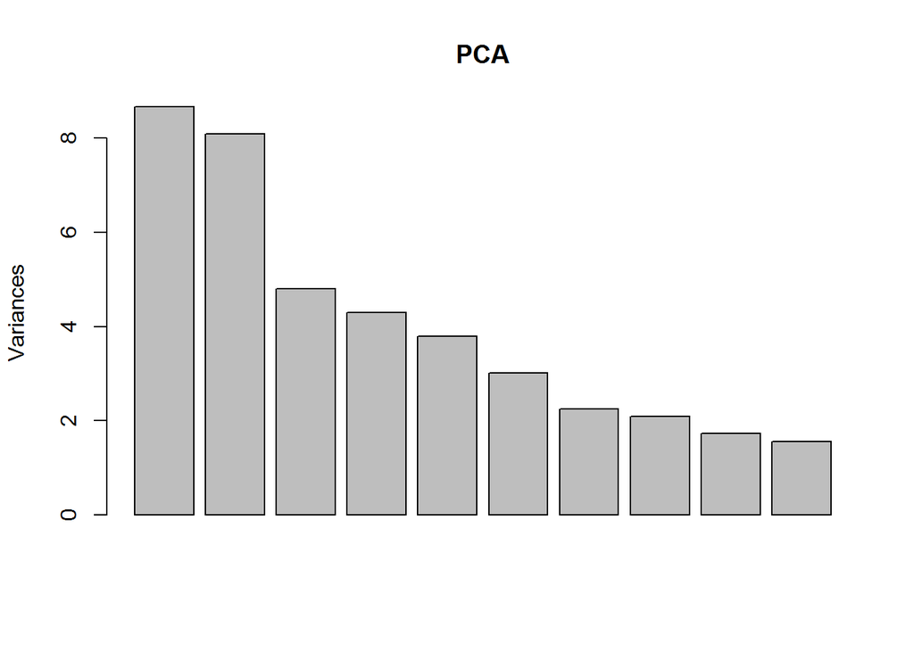

```r
PCA <- prcomp(training[,-55], scale.=TRUE)
plot(PCA)
```

As an aside, due to the constraints of the assignment a random forest model was used to maximize predictability. While this may make interpreting the model more difficult, it is likely to improve predictive ability. It may also be possible to use such a model to understand why a set of motions is triggeirng an incorrect performance class (which would be ideal in a practical situation, as simply indicating it is wrong does not provide sufficient feedback to correct the issue).

```r
 set.seed(54321)
baseModel <- train(classe ~ . , data=training)
baseModel$finalModel
```

```
##
## Call:
##  randomForest(x = x, y = y, mtry = param$mtry)
##                Type of random forest: classification
##                      Number of trees: 500
## No. of variables tried at each split: 28
##
##         OOB estimate of  error rate: 0.22%
## Confusion matrix:
##      A    B    C    D    E class.error
## A 4184    1    0    0    0   0.0002389
## B    5 2841    2    0    0   0.0024579
## C    0    6 2557    4    0   0.0038956
## D    0    0    7 2403    2   0.0037313
## E    0    0    3    2 2701   0.0018477
```

Due to the predicted perfomance of the PCA free model and the processor constraints, no PCA model was built into this report.

# Cross Validation

The random forest method for caret’s train function includes built in cross validation (holding cases in reserve to test built trees with). As noted above the estimated error rate is .22%.

```r
baseResults <- predict(baseModel,testing)
table(baseResults,testing$classe)
```

```
##
## baseResults    A    B    C    D    E
##           A 1395    2    0    0    0
##           B    0  947    0    0    0
##           C    0    0  852    1    0
##           D    0    0    3  802    1
##           E    0    0    0    1  900
```

```r
sum(baseResults == testing$classe)/length(baseResults)
```

```
## [1] 0.9984
```

# Final Testing

Running the code from the course site to generate files to submit. Which went well.

```r
pml_write_files = function(x){
  n = length(x)
   for(i in 1:n){
     filename = paste0("problem_id_",i,".txt")
     write.table(x[i],file=filename,quote=FALSE,row.names=FALSE,col.names=FALSE)
     }
  }
check <- read.csv("pml-testing.csv")
finalResults <- predict(baseModel,check)
pml_write_files(finalResults)
```